# Determinantes da Proficiência em Língua Portuguesa no SAEB 2019: Perfil dos alunos do 9º ano no Estado de Pernambuco

Luiz Fernando Oliveira do Nascimento

03/08/2021

## Resumo

O presente trabalho constitui uma estimação dos fatores determinantes da proficiência em Língua Portuguesa de alunos do 9º ano do ensino fundamental no Estado de Pernambuco, no SAEB 2019. Essa estimação é feita utilizando o modelo de regressão logística, para verificar quais variáveis referente ao perfil do aluno exercem maior impacto na proficiência em Língua Portuguesa no SAEB, exame aplicado pelo Ministério da Educação (MEC) a cada dois anos para verificar o nível de proficiência dos alunos dos ensinos fundamental e médio em Língua Portuguesa e Matemática. Por fim, o resultado encontrado é que as variáveis que indicam reprovação e trabalho fora de casa são as que impactam negativamente o desempenho do aluno, sendo levantada uma hipótese acerca desse resultado.

**Palavras-Chave:** Economia da Educação; SAEB; Língua Portuguesa; Proficiência.

## Introdução

A Economia da Educação pode ser descrita como a área da ciência econômica que estuda as relações econômicas ligadas ao nível de escolaridade. Essa relação pode ser medida através da chamada teoria do capital humano, descrito como o conjunto de habilidades, técnicas e conhecimentos que podem influenciar a produção de valor econômico (MELLO, 1991). Segundo Shirasu e Arraes (2015), a educação é tida como o principal fator capaz de afetar a produtividade do trabalho. Isso porque é possível distinguir os trabalhadores mais habilidosos dos menos habilidosos através de indicadores de produtividade do trabalho. Essa diferença está quase sempre relacionada ao nível de estudo e indivíduos com alto nível de escolaridade são àqueles que apresentam mais condições de superar a pobreza. As mudanças tecnológicas têm propiciado uma demanda por mão de obra cada vez mais qualificada. Essa nova realidade do processo produtivo é relacionada à automação das atividades industriais e ao surgimento de novos postos de trabalho no setor de informática e tecnologia. Com isso, o papel da educação de base tem sido cada vez mais relevante para a boa formação dos profissionais que atuarão no mercado futuramente (MELLO, 1991). Para além do “acúmulo de informações segmentadas, torna-se mais importante dominar as formas de acesso à informação e desenvolver a capacidade de reunir e organizar aquelas que são relevantes” (MELLO, 1991). Dessa forma, o domínio dos instrumentos de linguagem e matemática assumem papel de destaque na formação daqueles estudantes que desejam se adaptar à nova realidade. Um domínio adequado dos conteúdos de Língua Portuguesa e Matemática permitem ao estudante a compreensão de uma série de conteúdos científicos e o desenvolvimento e “formação de habilidades cognitivas tais como: compreensão, pensamento analítico e abstrato, flexibilidade de raciocínio para entender situações novas e solucionar problemas” (MELLO, 1991). Fundos específicos para o financiamento da educação pública só foram criados a partir da segunda metade da década de 1990 (SHIRASU; ARRAES, 2015). Mesmo gastando com educação como proporção do PIB mais que média dos países da OCDE (SHIRASU; ARRAES, 2015), o Brasil apresenta diversos entraves que impossibilitam o país de avançar no setor, além de colecionar fracos desempenhos em avaliações internacionais, como o PISA (*Programme for International Student Assess*). Dessa forma, o Brasil entrou no século XXI sem estar preparado para as transformações que vinham acontecendo desde os anos 1970. Isso levou a uma baixa qualificação que acentua o problema do emprego entre os mais jovens, atingindo uma taxa de desemprego de 29,8% entre os jovens de 18 a 24 anos ao final de 2020, uma alta de 6 pontos percentuais em relação ao ano anterior (IBGE, 2021). Além do fraco desempenho em avaliações, o baixo nível de proficiência em Língua Portuguesa e Matemática está diretamente relacionado aos altos índices de reprovação e abandono escolar, o que aprofunda o problema. Um estudante que apresenta pouco domínio dos conteúdos básicos na etapa final do ensino fundamental, provavelmente terá dificuldades em acompanhar os conteúdos do ensino médio, levando à reprovação escolar e/ou ao abandono (SHIRASU; ARRAES, 2015). Entender, então, quais são os fatores que levam ao baixo desempenho em Língua Portuguesa e Matemática se faz necessário para diagnosticar a fonte primária do problema e, assim, elaborar políticas públicas em educação capazes de solucioná-los de maneira estrutural e eficiente. Bassetto (2019) estudou o impacto da renda e da escolaridade materna no desempenho dos alunos do estado de São Paulo na prova de matemática do Sistema de Avaliação do Rendimento Escolar do Estado de São Paulo (SARESP). A escolha das variáveis é justificada pela autora porque “a determinante para o aspecto socioeconômico está ligada diretamente à renda dos pais e, consequentemente, ao nível educacional e cultural dos mesmos. Dessa forma, os recursos financeiros que estão à disposição dos pais se convertem em investimento educacional para os filhos, considerando que um menor nível educacional proporciona um menor nível socioeconômico em um longo prazo” (BASSETTO, 2019).Os resultados obtidos pela autora permitiram concluir que a renda e a escolaridade da mãe exercercem influência só até determinada faixa de renda e a escolaridade da mãe apresenta maior influência no desempenho dos alunos com nível de proficiência menor, mas não nos de proficiência mais alta (BASSETTO, 2019). A proficiência em Língua Portuguesa pode ser testada empiricamente através de três grupos de variáveis observáveis: variáveis do aluno, da família e da escola. As variáveis do aluno são àquelas que dizem respeito ao comprometimento do mesmo com a disciplina e fatores socioeconômicos, que podem ser medidos pelo fato do aluno exercer profissão remunerada ou não. As variáveis da família são àquelas que relacionam a escolaridade dos pais e o incentivo a estudar dados aos filhos com a proficiência. E, por fim, as variáveis da escola são àquelas que relacionam a proficiência dos alunos ao nível de capacitação dos professores e à infraestrutura básica da unidade de ensino. Neste trabalho, serão utilizadas apenas as variáveis do aluno, na tentativa de conhecer o perfile as característica do aluno que consegue atingir determinado nível de proficiência em língua portuguesa no 9º ano do ensino fundamental.

## Aspectos Metodológicos

### Fonte e Tratamento de Dados

Os dados utilizados na estimação do modelo para os fatores determinantes da proficiência em Língua Portuguesa são os resultados obtidos por meio das Informações das respostas ao questionário e das proficiências dos alunos do 9º ano do Ensino Fundamental na prova do SAEB 2019, disponibilizado pelo Instituto Nacional de Estudos e Pesquisas Educacionais Anísio Teixeira (INEP). A Tabela 1 apresenta as variáveis utilizadas na estimação do modelo, sua descrição e o sinal esperado de cada variável após a estimação da regressão logística.

```r
library(tidyverse)
dados <- TS_ALUNO_9EF %>%
  select(ID_ALUNO, ID_UF, PROFICIENCIA_LP_SAEB, TX_RESP_Q002, ID_TURNO,
         TX_RESP_Q006B, TX_RESP_Q018B,
         TX_RESP_Q017E, TX_RESP_Q015) %>%
  filter(ID_UF == 26,
         PROFICIENCIA_LP_SAEB != is.na(PROFICIENCIA_LP_SAEB),
         TX_RESP_Q002 != "F") %>%
  mutate(TX_RESP_Q002 = recode(TX_RESP_Q002,
                        "A" = "Branco", "B" = "Não branco",
                        "C" = "Não branco", "D" = "Não branco",
                        "E" = "Não branco"),
         TX_RESP_Q006B = recode(TX_RESP_Q006B,
                               "A" = "FALSE", "B" = "TRUE",
                               "C" = "TRUE"),
         TX_RESP_Q017E = recode(TX_RESP_Q017E,
                                "A" = "FALSE", "B" = "TRUE",
                                "C" = "TRUE", "D" = "TRUE"),
         TX_RESP_Q018B = recode(TX_RESP_Q018B,
                                "A" = "FALSE", "B" = "TRUE",
                                "C" = "TRUE"),
         TX_RESP_Q015 = recode( TX_RESP_Q015,
                               "A" = "FALSE", "B" = "TRUE",
                               "C" = "TRUE"),
         Nivel_3 = PROFICIENCIA_LP_SAEB >= 250,
         Turno_N = ID_TURNO == 3)

dados <- dados %>% mutate(TX_RESP_Q002 = as_factor(TX_RESP_Q002),
       Nivel_3 = as.numeric(Nivel_3)) %>%
  filter(TX_RESP_Q002 != "." & TX_RESP_Q002 != "*",
         TX_RESP_Q006B != "." & TX_RESP_Q006B != "*",
         TX_RESP_Q015 != "." & TX_RESP_Q015 != "*",
         TX_RESP_Q017E != "." & TX_RESP_Q017E != "*",
         TX_RESP_Q018B != "." & TX_RESP_Q018B != "*")
```

**Tabela 1 - Variáveis do Modelo Logit Para Determinantes da Proficiência em Língua Portuguesa de alunos do 9º ano de Pernambuco no SAEB 2019**

| Variáveis | Descrição das variáveis | Sinal esperado |
| --- | --- | --- |
| Nivel_3 | Nota igual ou maior que 250 em LP | Variável Dependente |
| TX_RESP_Q002 | Cor/raça do aluno | + ou - |
| TX_RESP_Q006B | Mãe/pai incentiva o aluno a estudar | + |
| Turno_N | Aulas em turno noturno | - |
| TX_RESP_Q015 | Aluno já foi reprovado | - |
| TX_RESP_Q017E | Aluno trabalha fora de casa | - |
| TX_RESP_Q018B | Aluno costuma ler livros | + |

Fonte: Elaboração própria.

**Figura 1 - Esquema de Operacionalização do Modelo Teórico**

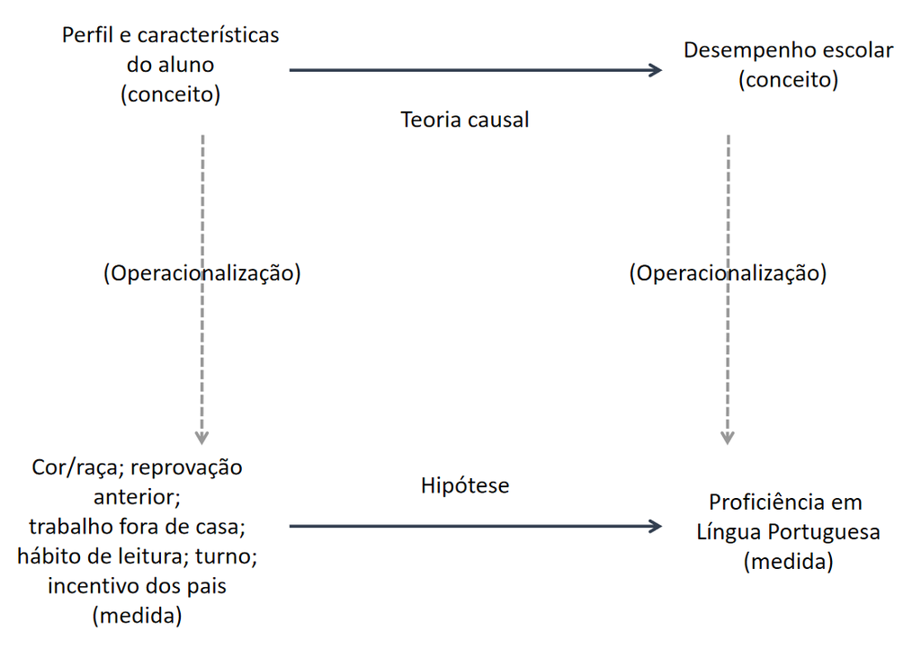

Fonte: Elaboração própria com base em Kellstedt e Whitten (2018).

Conforme demonstrado na figura, o modelo teórico a ser utilizado considera que o desempenho escolar é derivado do perfil e características do aluno. Do ponto de vista teórico, características da família e da escola em que esse indivíduo está inserido também exercem influência sobre o seu desempenho. Por simplicidade, este trabalho considera o trabalho fora de casa e o incentivo dos pais ao aluno estudar como reflexos do aspecto familiar e socieconômico do mesmo. Por ser uma simplificação da realidade traduzida por duas variáveis proxy, a validade dos resultados pode ser questionada. No entanto, é razoável supor que alunos que trabalham fora de casa estão inseridos em condições socioeconômicas adversas, sendo isso que os motiva a buscar trabalho na idade escolar. Vale destacar que, pela relação idade/série do MEC e INEP, o 9º ano do ensino fundamental deve ser cursado por alunos que completam 14 ou 15 anos até o mês de outubro do ano de referência. Ou seja, do ponto de vista legal, alunos matriculados no 9º ano podem ser contratados formalmente como jovens aprendizes. Infelizmente, não é possível filtrar o tipo de trabalho exercido pelos alunos, nem se o mesmo é do tipo formal ou informal. O incentivo dos pais representa, por hipótese, o grau de envolvimento dos mesmos com a vida escolar de seus filhos. Novamente, trata-se de uma simplificação da realidade. Como o INEP não aplica questionários aos pais e responsáveis, está sendo considerado o “incentivo autodeclarado” pelo aluno no seu questionário. Nenhuma das variáveis operacionalizadas trata das características físicas das escolas e/ou do grau de formação dos professores. A exclusão desse nicho de variáveis implica que tais características passam a compor o erro. Logo, está sendo admitida a hipótese (ainda que de maneira implítica) de que as escolas apresentam características muito semelhantes, o que é irrealista, mas necessário para manter a parcimônia do modelo, visto que o objetivo central é conhecer o perfil do aluno por suas características pessoais e não por atributos externos ao seu controle. Devido à restrição de disponibilidade dos dados, não é possível incorporar outras características pessoais, como por exemplo sexo biológico e/ou identidade de gênero, ao modelo. Idealmente, a variável de desempenho utilizada deveria conter a proficiência não só em língua portuguesa, como nas demais disciplinas. Ou seja, o desempenho escolar seria melhor operacionalizado se estivesse disponível alguma medida similar ao Coeficiente de Rendimento Acadêmico (CRA) adotado na maioria das universidades. Ainda assim, é razoável supor que o desempenho nas demais disciplinas, e, consequentemente, a própria trajetória escolar do aluno está diretamente ligado ao seu desempenho na sua língua materna. Como algumas das competências avaliadas pelo SAEB dizem respeito à capacidade demonstrada no exame pelo aluno de interpretar textos e compreender a ideia geral de fragmentos de textos, é possível supor que um aluno que não apresente tais capacidade não seja capaz de compreender textos de caráter mais técnicista. Ou seja, um aluno com baixo desempenho em língua portuguesa quase que certamente apresentará baixo desempenho em ciências, geografia, história e nas demais disciplinas. Outra possibilidade seria considerar como proxy para o desempenho escolar a nota obtida na prova de matemática do SAEB 2019, porém, não foi identificada nos questionários aplicados pelo INEP outra pergunta equivalente ao hábito de leitura que fosse capaz de exercer efeito positivo no aprendizado de matemática. Além disso, o aprendizado em matemática está associado ao aprendizado em língua portuguesa, visto que é pouco provável que um aluno que apresente pouca habilidade de interpretação de texto seja capaz de retirar todas as informações necessárias à resolução dos problemas propostos dos fragmentos de texto fornecidos no enunciado das questões da prova.

### Modelo Empírico Adotado

Figueira (2006), diz que em situações em que se deseja utilizar uma variável dependente que qualitativa categórica, não é possível encontrar estimadores consistentes utilizando o método de Mínimos Quadrados Ordinários (MQO). Uma opção, é tentar encontrar a probabilidade de um determinado evento ocorrer, utilizando o modelo de regressão logística. Embora seja possível utilizar o Modelo de Probabilidade Linear (MPL), que utiliza o MQO para encontrar a probabilidade um evento ocorrer, não é possível garantir que o parâmetro estimado se situará no intervalo entre 0 e 1. Como qualquer probabilidade de um evento *Y* ocorrer dado a ocorrência de *X* deve estar necessariamente no intervalo entre 0 e 1 e o MQO não leva em conta tal restrição, o uso do MPL pode gerar resultados que não obedeçam a lógica das probabilidades, ou seja, é possível que se encontrem resultados fora dos limites lógicos (GUJARATI; PORTER, 2011). O uso do modelo logit permite encontrar o logaritmo de razão das chances *L*, que é linear em *X* (variável dependente), mas não é linear nas probabilidades. Ou seja, diferentemente do que ocorre com o MPL, as probabilidades não aumentam de forma linear com a variável *X*. É importante destacar que o modelo logit permite a inclusão de quantas variáveis independentes estiverem associadas teoricamente à variável dependente. Encontrar um *L* positivo, significa dizer que as chances de um determinado evento ocorrer dado a ocorrência de *X* aumentam, enquanto que um *L* negativo indica que as chances de um determinado evento ocorrer na presença de *X* diminuem. (GUJARATI; PORTER, 2011). De acordo com Gujarati e Porter (2011), Diferentemente do que ocorre nos modelos estimados por MQO, a significância estatística do modelo logit é verificada pela estatística Z (normal), isso é resultado do uso do Método de Máxima Verossimilhança (MV) para a estimação dos coeficientes. Ainda segundo os autores. a significância global do modelo não é medida pelo *R^2* convencional, visto que essa medida não significativa em modelos de regressores binários. Nesses modelos, os sinais esperados dos coeficientes e suas significâncias assumem importância maior que a qualidade do ajustamento. Ainda assim, a significância conjunta dos parâmetros estimados, medida pelo teste *F* no MQO, pode ser verificada pela estatística de Razão de Verossimilhança. A equação (1) apresenta o modelo econométrico a ser estimado, utilizando modelo de regressão logit, um modelo resposta qualitativa não-linear que apresenta distribuição logística. A equação abaixo informa que o modelo empírico estima a probabilidade, medida pelos efeitos marginais, do aluno apresentar nota superior a 250 em Língua Portuguesa na Prova Brasil para cada variável apresentada na Tabela 1.

$$Pi = F(Yi) = \frac{1}{1+e^-(\alpha +\beta Xi)}$$

Para a estimação do modelo, todas as variáveis qualitativas foram transformadas em variáveis dicotômicas. O objetivo é simplicar a análise transformando variáveis que, por natureza, possuem mais de duas categorias em variáveis binárias. A escolha pela classificação da variável de cor/raça entre brancos e não brancos é advinda do perfil populacional do estado de Pernambuco, onde mais de 35% das pessoas se autodeclaram brancas, com os 65% sendo classificados como não brancos para fins desta pesquisa. Conforme informado anteriormente, essa classificação não busca identificar qualquer fator determinístico no desempenho escolar pelo perfil racial, apenas se busca verificar se existe uma diferença de desempenho escolar entre as duas categorias, o que poderia servir de base para a construção de políticas públicas focalizadas no grupo que apresenta de menor desempenho. Da mesma forma, as variáveis de incentivo ao estudo, trabalho fora de casa e hábito de leitura são originalmente disponibilizadas pelo INEP divididas em mais categorias. Novamente, por simplicidade, essas variáveis foram transformadas em binárias, ainda que seja razoável supor que um aluno que trabalhe 10 horas por semana disponha de menos tempo livre para os estudos do que um aluno que trabalhe 5 horas por semana. Da mesma forma, pressupõe-se que ler mais livros afeta mais o desempenho escolar do que ler menos livros, bem como ser mais incentivado pode afetar mais do que ser pouco incentivado. No entanto, a busca não é por verificar o efeito marginal de 1 livro ou de 1 hora de trabalho, mas sim entender se o hábito de ler ou de trabalhar afetam o desempenho. Assim, a redução no número de categorias em cada variável simplifica a análise.

## Análise dos Resultados

Esta seção de resultados está estruturada em duas subseções: na primeira são apresentadas algumas estatísticas descritivas e testes de hipóteses das variáveis utilizadas nos modelos estimados, na segunda são apresentados os resultados estimados pelo modelo logit e, por fim, é apresentada uma avaliação dos modelos estimados.

### Descrição dos Dados e Testes de Hipóteses

A análise das estatísticas descritivas das variáveis permitem conhecer algumas das propriedades da série estudada, sendo este o primeiro passo para verificar o formato e a distribuição de frequências da série estudada. O histograma abaixo (Figura 2) apresenta o formato da distribuição das notas obtidas pelos alunos do 9º ano do Ensino Fundamental de Pernambuco em Língua Portuguesa no SAEB 2019.

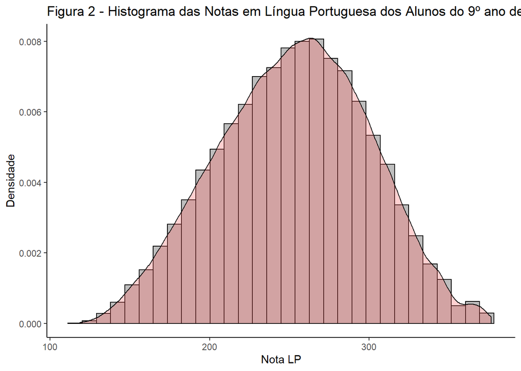

```r
library(ggplot2)
ggplot(dados, aes(x = PROFICIENCIA_LP_SAEB)) +
  geom_histogram(aes(y =..density..), colour="black", fill="gray")+
  geom_density(alpha =.3, fill ="#FF6666") +
  labs(title ="Figura 2 - Histograma das Notas em Língua Portuguesa dos Alunos do 9º ano de Pernambuco no SAEB 2019",
       x ="Nota LP", y = "Densidade")+
  theme_classic()
```

O histograma apresenta um formato parecido com o “formato de sino”, característico das distribuições normais. Chama atenção o fato de que a quantidade de observações próximas a cauda à esquerda aparenta ser levemente maior que as da cauda à direita. Ou seja, a quantidade de alunos com nota igual ou inferior a 200 aparenta ser um pouco maior que a quantidade de alunos com nota igual ou superior a 300 pontos. A maior parte das notas se situa ao centro da distribuição. A Tabela 2 apresenta os resultados estimados para os testes de normalidade da variável.

```r
library(fBasics)
skewness(dados$PROFICIENCIA_LP_SAEB)
```

```
## [1] -0.07665083
## attr(,"method")
## [1] "moment"
```

```r
kurtosis(dados$PROFICIENCIA_LP_SAEB)
```

```
## [1] -0.4581713
## attr(,"method")
## [1] "excess"
```

```r
jarqueberaTest(dados$PROFICIENCIA_LP_SAEB)
```

```
##
## Title:
##  Jarque - Bera Normalality Test
##
## Test Results:
##   STATISTIC:
##     X-squared: 724.5073
##   P VALUE:
##     Asymptotic p Value: < 0.00000000000000022
##
## Description:
##  Wed Aug 11 19:19:13 2021 by user: luizf
```

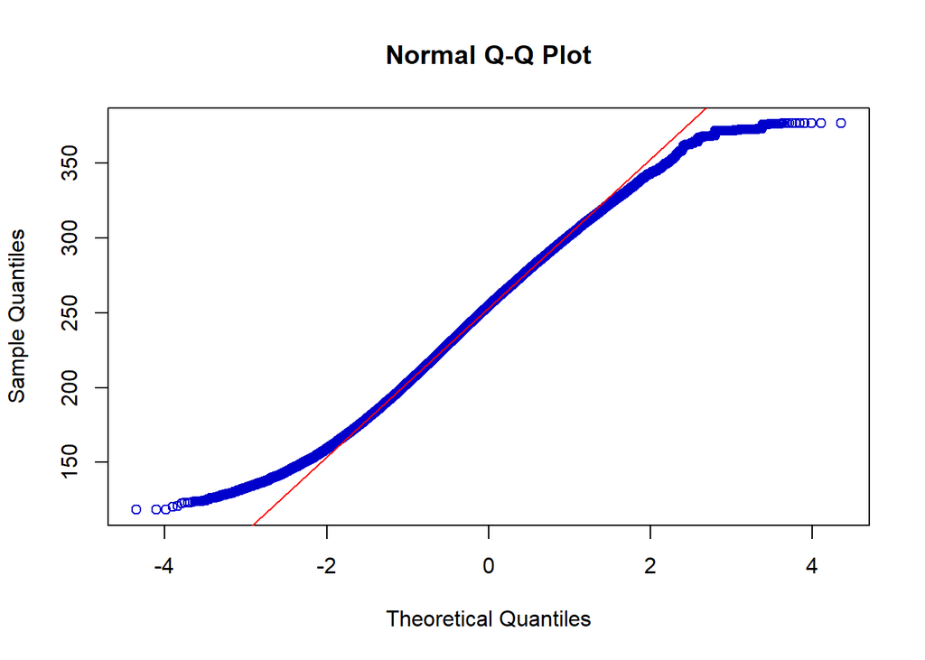

```r
qqnorm(dados$PROFICIENCIA_LP_SAEB, col="blue3")
qqline(dados$PROFICIENCIA_LP_SAEB, col = "red")
```

**Tabela 2 - Testes de Normalidade das Notas em Língua Portuguesa dos Alunos do 9º ano de Pernambuco no SAEB 2019**

| Testes | PROFICIENCIA_LP_SAEB |
| --- | --- |
| Simetria | -0.0766 |
| Curtose | -0.4581 |
| Jarque-Bera | 724.5073 p-valor: 0,000 |

Fonte: Elaboração própria a partir de dados do SAEB 2019.

Segundo Maia (2016), a simetria é definida como sendo o grau de afastamento de uma distribuição em relação a distribuição normal, como a estatística encontrada é menor do que zero, tem-se que a distribuição dos dados é assimétrica negativa, o que significa que “existirão mais dados da série maiores do que a médiaa, porém a curva de distribuição terá uma cauda mais longa para os dados menores do que a média” (MAIA, 2016). Ainda segundo o mesmo autor, a Curtose representa o grau de achatamento de uma distribuição, quando a estatística encontrada é menor do que 3 (sendo 3 o valor de referência para uma distribuição normal), a mesma é denominada platicúrtica e apresenta alta variabilidade. O teste de Jarque-Bera permite verificar se uma distribuição é normal, tendo por hipótese nula a normalidade da distribuição. Ou seja, pela observação do p-valor pode-se rejeitar a hipótese nula do teste Jarque-Bera, o que significa que a distribuição das notas em língua portuguesa não apresenta características de uma distribuição normal. O gráfico QQ-Plot é outra forma de avaliar se uma distribuição é uma distribuição normal. Quanto mais próximos os pontos azuis estiverem da linha vermelha, mais próxima estará a distribuição em questão de uma distribuição normal. O gráfico QQ-Plot mostra que as observações localizadas próximas as pontas se afastam da linha vermelha, sendo essa uma forma gráfica de confirmar que a distribuição das notas não é uma distribuição normal. A Tabela 3 apresenta as estatísticas descritivas das notas obtidas em língua portuguesa distribuídas entre as categorias estudadas.

```r
# Nota por Cor/raça
dados %>% group_by(TX_RESP_Q002) %>%
  summarise(media = mean(PROFICIENCIA_LP_SAEB, na.rm = TRUE),
            min = min(PROFICIENCIA_LP_SAEB, na.rm = TRUE),
            max = max(PROFICIENCIA_LP_SAEB, na.rm = TRUE),
            sd = sd(PROFICIENCIA_LP_SAEB, na.rm = TRUE),
            median = median(PROFICIENCIA_LP_SAEB, na.rm = TRUE))
```

```
## # A tibble: 2 x 6
##   TX_RESP_Q002 media   min   max    sd median
##   <fct>        <dbl> <dbl> <dbl> <dbl>  <dbl>
## 1 Não branco    251.  118.  377.  46.5   253.
## 2 Branco        259.  120.  377.  48.6   262.
```

```r
# Nota trabalha/não trabalha
dados %>% group_by(TX_RESP_Q017E) %>%
  summarise(media = mean(PROFICIENCIA_LP_SAEB, na.rm = TRUE),
            min = min(PROFICIENCIA_LP_SAEB, na.rm = TRUE),
            max = max(PROFICIENCIA_LP_SAEB, na.rm = TRUE),
            sd = sd(PROFICIENCIA_LP_SAEB, na.rm = TRUE),
            median = median(PROFICIENCIA_LP_SAEB, na.rm = TRUE))
```

```
## # A tibble: 2 x 6
##   TX_RESP_Q017E media   min   max    sd median
##   <chr>         <dbl> <dbl> <dbl> <dbl>  <dbl>
## 1 FALSE          256.  118.  377.  46.8   258.
## 2 TRUE           242.  118.  377.  46.8   243.
```

```r
# Nota Reprovado
dados %>% group_by(TX_RESP_Q015) %>%
  summarise(media = mean(PROFICIENCIA_LP_SAEB, na.rm = TRUE),
            min = min(PROFICIENCIA_LP_SAEB, na.rm = TRUE),
            max = max(PROFICIENCIA_LP_SAEB, na.rm = TRUE),
            sd = sd(PROFICIENCIA_LP_SAEB, na.rm = TRUE),
            median = median(PROFICIENCIA_LP_SAEB, na.rm = TRUE))
```

```
## # A tibble: 2 x 6
##   TX_RESP_Q015 media   min   max    sd median
##   <chr>        <dbl> <dbl> <dbl> <dbl>  <dbl>
## 1 FALSE         261.  120.  377.  46.3   263.
## 2 TRUE          233.  118.  376.  43.5   232.
```

```r
# Nota Turno
dados %>% group_by(Turno_N) %>%
  summarise(media = mean(PROFICIENCIA_LP_SAEB, na.rm = TRUE),
            min = min(PROFICIENCIA_LP_SAEB, na.rm = TRUE),
            max = max(PROFICIENCIA_LP_SAEB, na.rm = TRUE),
            sd = sd(PROFICIENCIA_LP_SAEB, na.rm = TRUE),
            median = median(PROFICIENCIA_LP_SAEB, na.rm = TRUE))
```

```
## # A tibble: 2 x 6
##   Turno_N media   min   max    sd median
##   <lgl>   <dbl> <dbl> <dbl> <dbl>  <dbl>
## 1 FALSE    253.  118.  377.  47.1   255.
## 2 TRUE     257.  138.  368.  46.9   256.
```

**Tabela 3 - Estatísticas Descritivas das Notas em Língua Portuguesa no SAEB 2019 de Alunos do 9º ano de Pernambuco por Categoria de Análise**

| Categorias de Notas | Mínimo | Média | Mediana | Máximo | Desvio-padrão |
| --- | --- | --- | --- | --- | --- |
| Brancos | 120,00 | 259,00 | 262,00 | 377,00 | 48,60 |
| Não brancos | 118,00 | 251,00 | 253,00 | 377,00 | 46,50 |
| Trabalha | 118,00 | 242,00 | 243,00 | 377,00 | 46,80 |
| Não trabalha | 118,00 | 256,00 | 258,00 | 377,00 | 46,80 |
| Reprovado | 118,00 | 233,00 | 232,00 | 376,00 | 43,50 |
| Não reprovado | 120,00 | 261,00 | 263,00 | 377,00 | 46,30 |
| Turno Diurno | 118,00 | 253,00 | 255,00 | 377,00 | 47,10 |
| Turno Noturno | 138,00 | 257,00 | 256,00 | 368,00 | 46,90 |

Fonte: Elaboração própria a partir de dados do SAEB 2019.

De forma geral, as estatísticas apresentadas demonstram haver diferenças nas médias entre os grupos avaliados. Conforme o esperado, o grupo de alunos que não trabalham e que não foram reprovados apresentaram média e mediana maiores que as do grupos de alunos que trabalham fora de casa e/ou foram reprovados. Também é possível destacar que o grupo de alunos brancos apresentaram notas mínimas, média e mediana maiores que o grupo de alunos não brancos, mas a dispersão em torno da média, apontada pelo desvio-padrão, foi menor para o segundo grupo. Surpreendeu o fato de que alunos matriculados no turno noturno terem apresentado média e nota mínima superior às notas dos alunos matriculados no período diurno (matutinou ou vespertino). A simples observação das diferenças entre as médias não permite afirmar que existe uma diferença estatísticamente significante entre elas. Para isso, é necessário verificar se existe diferença estatística por meio de testes de hipóteses adequados para cada tipo de variável. A Tabela 4 apresenta os testes de hipóteses estimados.

```r
# Teste t
t.test(PROFICIENCIA_LP_SAEB ~ TX_RESP_Q002, data = dados)
```

```
##
##  Welch Two Sample t-test
##
## data:  PROFICIENCIA_LP_SAEB by TX_RESP_Q002
## t = -19.516, df = 26640, p-value < 0.00000000000000022
## alternative hypothesis: true difference in means is not equal to 0
## 95 percent confidence interval:
##  -9.048888 -7.397166
## sample estimates:
## mean in group Não branco     mean in group Branco
##                 251.2471                 259.4701
```

```r
t.test(PROFICIENCIA_LP_SAEB ~ Turno_N, data = dados)
```

```
##
##  Welch Two Sample t-test
##
## data:  PROFICIENCIA_LP_SAEB by Turno_N
## t = -1.7788, df = 479.14, p-value = 0.0759
## alternative hypothesis: true difference in means is not equal to 0
## 95 percent confidence interval:
##  -8.0891575  0.4021207
## sample estimates:
## mean in group FALSE  mean in group TRUE
##            253.0884            256.9319
```

```r
t.test(PROFICIENCIA_LP_SAEB ~ TX_RESP_Q006B, data = dados)
```

```
##
##  Welch Two Sample t-test
##
## data:  PROFICIENCIA_LP_SAEB by TX_RESP_Q006B
## t = -4.9568, df = 1740.2, p-value = 0.0000007865
## alternative hypothesis: true difference in means is not equal to 0
## 95 percent confidence interval:
##  -9.045331 -3.916499
## sample estimates:
## mean in group FALSE  mean in group TRUE
##             246.778             253.259
```

```r
t.test(PROFICIENCIA_LP_SAEB ~ TX_RESP_Q015, data = dados)
```

```
##
##  Welch Two Sample t-test
##
## data:  PROFICIENCIA_LP_SAEB by TX_RESP_Q015
## t = 75.125, df = 38530, p-value < 0.00000000000000022
## alternative hypothesis: true difference in means is not equal to 0
## 95 percent confidence interval:
##  26.65923 28.08759
## sample estimates:
## mean in group FALSE  mean in group TRUE
##            260.5664            233.1930
```

```r
t.test(PROFICIENCIA_LP_SAEB ~ TX_RESP_Q017E, data = dados)
```

```
##
##  Welch Two Sample t-test
##
## data:  PROFICIENCIA_LP_SAEB by TX_RESP_Q017E
## t = 34.461, df = 26328, p-value < 0.00000000000000022
## alternative hypothesis: true difference in means is not equal to 0
## 95 percent confidence interval:
##  13.45481 15.07765
## sample estimates:
## mean in group FALSE  mean in group TRUE
##            256.2524            241.9862
```

```r
#Qui-quadrado
chisq.test(dados$Nivel_3, dados$TX_RESP_Q017E)
```

```
##
##  Pearson's Chi-squared test with Yates' continuity correction
##
## data:  dados$Nivel_3 and dados$TX_RESP_Q017E
## X-squared = 759.5, df = 1, p-value < 0.00000000000000022
```

```r
chisq.test(dados$TX_RESP_Q017E, dados$Turno_N)
```

```
##
##  Pearson's Chi-squared test with Yates' continuity correction
##
## data:  dados$TX_RESP_Q017E and dados$Turno_N
## X-squared = 107.42, df = 1, p-value < 0.00000000000000022
```

**Tabela 4 - Testes de Hipóteses Estimados**

| **Teste t** | Estatística do teste | p-valor |
| --- | --- | --- |
| PROF_LP ~ TX_RESP_Q002 | -19,516 | 0,0000 |
| PROF_LP ~ Turno_N | -1,7788 | 0,0759 |
| PROF_LP ~ TX_RESP_Q006B | -4,9568 | 0,0000 |
| PROF_LP ~ TX_RESP_Q015 | 75,125 | 0,0000 |
| PROF_LP ~ TX_RESP_Q017E | 34,461 | 0,0000 |
| **Teste Qui-quadrado** |  |  |
| Nivel_3 ~ TX_RESP_Q017E | 759,50 | 0,0000 |
| TX_RESP_Q017E ~ Turno_N | 107,42 | 0,0000 |

Fonte: Elaboração própria a partir de dados do SAEB 2019.

O teste t verifica se existe diferença entre as médias de variáveis contínuas por cada categoria de uma variável categória. Foram realizados 5 testes para verificar a associção entre a nota obtida por alunos em língua portuguesa no SAEB 2019 e as categorias de cor/raça, turno, incentivo dos pais, reprovação e trabalho fora de casa.A hipótese nula do teste nos diz que a diferença entre as médias entre as categorias é igual a zero, ou seja, aceitar a hipótese nula significa dizer que as médias observadas na Tabela 3 são iguais entre as categorias de análise. Pela observação do p-valor e dos intervalos de confianças, pode-se inferir que a diferença entre as médias é estatisticamente diferente de zero entre as categorias da maioria das variáveis, com exceção da variável de turno escolar. Neste caso, o intervalo de confiança encontrado inclui o valor zero e o p-valor encontra-se acima de 0,05, não havendo segurança para a rejeição da hipótese nula. O teste de Qui-quadrado foi estimado para verificar a associação entre entre as variáveis categóricas. A hipótese nula desse teste diz que não há associação entre duas variáveis categóricas quaisquer. Primeiro, verificou-se se existe alguma associação entre alcançar uma nota igual ou superior a 250 pontos em língua portuguesa no SAEB (nível 3 ou superior, na escala do INEP) e o trabalho fora de casa. Posteriormente verificou-se a associação entre o trabalho fora de casa e o período noturno de aulas. Para os dois casos, pôde-se rejeitar a hipótese nula de que as variáveis não estão associadas de alguma forma, tanto pelos valores obtidos para a estatística do teste, quanto pela observação do p-valor. Com a verificação da existência de associação entre as variáveis, foi possível dar início à estimação do modelo de regressão logística, cujo os resultados encontrados estão apresentados na na seção a seguir.

### Estimação do Modelo Logit

```r
logit <- glm(Nivel_3 ~ TX_RESP_Q002 + TX_RESP_Q006B + Turno_N +
            TX_RESP_Q015 + TX_RESP_Q017E + TX_RESP_Q018B,
             data = dados, family = binomial)
summary(logit)
```

```
##
## Call:
## glm(formula = Nivel_3 ~ TX_RESP_Q002 + TX_RESP_Q006B + Turno_N +
##     TX_RESP_Q015 + TX_RESP_Q017E + TX_RESP_Q018B, family = binomial,
##     data = dados)
##
## Deviance Residuals:
##     Min       1Q   Median       3Q      Max
## -1.7002  -1.2514   0.8602   0.9895   1.7238
##
## Coefficients:
##                    Estimate Std. Error z value             Pr(>|z|)
## (Intercept)         0.10806    0.05233   2.065             0.038906 *
## TX_RESP_Q002Branco  0.26724    0.01828  14.618 < 0.0000000000000002 ***
## TX_RESP_Q006BTRUE   0.08410    0.05140   1.636             0.101835
## Turno_NTRUE         0.37287    0.09705   3.842             0.000122 ***
## TX_RESP_Q015TRUE   -0.97304    0.01732 -56.181 < 0.0000000000000002 ***
## TX_RESP_Q017ETRUE  -0.36416    0.01845 -19.740 < 0.0000000000000002 ***
## TX_RESP_Q018BTRUE   0.34428    0.01665  20.679 < 0.0000000000000002 ***
## ---
## Signif. codes:  0 '***' 0.001 '**' 0.01 '*' 0.05 '.' 0.1 ' ' 1
##
## (Dispersion parameter for binomial family taken to be 1)
##
##     Null deviance: 102877  on 74511  degrees of freedom
## Residual deviance:  98071  on 74505  degrees of freedom
## AIC: 98085
##
## Number of Fisher Scoring iterations: 4
```

[output not shown]

Fonte: Elaboração própria a partir de dados do SAEB 2019.

```r
logitIT <- glm(Nivel_3 ~ TX_RESP_Q002 + TX_RESP_Q006B + Turno_N +
              TX_RESP_Q015 + TX_RESP_Q017E + TX_RESP_Q018B +
              (Turno_N*TX_RESP_Q017E),
              data = dados, family = binomial)
summary(logitIT)
```

```
##
## Call:
## glm(formula = Nivel_3 ~ TX_RESP_Q002 + TX_RESP_Q006B + Turno_N +
##     TX_RESP_Q015 + TX_RESP_Q017E + TX_RESP_Q018B + (Turno_N *
##     TX_RESP_Q017E), family = binomial, data = dados)
##
## Deviance Residuals:
##     Min       1Q   Median       3Q      Max
## -1.6586  -1.2508   0.8600   0.9894   1.7246
##
## Coefficients:
##                               Estimate Std. Error z value            Pr(>|z|)
## (Intercept)                    0.10848    0.05233   2.073              0.0382
## TX_RESP_Q002Branco             0.26725    0.01828  14.618 <0.0000000000000002
## TX_RESP_Q006BTRUE              0.08407    0.05140   1.636              0.1019
## Turno_NTRUE                    0.28004    0.12707   2.204              0.0275
## TX_RESP_Q015TRUE              -0.97318    0.01732 -56.186 <0.0000000000000002
## TX_RESP_Q017ETRUE             -0.36609    0.01853 -19.757 <0.0000000000000002
## TX_RESP_Q018BTRUE              0.34437    0.01665  20.684 <0.0000000000000002
## Turno_NTRUE:TX_RESP_Q017ETRUE  0.21808    0.19513   1.118              0.2637
##
## (Intercept)                   *
## TX_RESP_Q002Branco            ***
## TX_RESP_Q006BTRUE
## Turno_NTRUE                   *
## TX_RESP_Q015TRUE              ***
## TX_RESP_Q017ETRUE             ***
## TX_RESP_Q018BTRUE             ***
## Turno_NTRUE:TX_RESP_Q017ETRUE
## ---
## Signif. codes:  0 '***' 0.001 '**' 0.01 '*' 0.05 '.' 0.1 ' ' 1
##
## (Dispersion parameter for binomial family taken to be 1)
##
##     Null deviance: 102877  on 74511  degrees of freedom
## Residual deviance:  98070  on 74504  degrees of freedom
## AIC: 98086
##
## Number of Fisher Scoring iterations: 4
```

[output not shown]

Fonte: Elaboração própria a partir de dados do SAEB 2019.

Conforme demonstra a Tabela 6, o coeficiente estimado para a variável de interação entre trabalho fora de casa e turno noturno não apresentou significância estatísitica, quando observados o Z e o p-valor, não sendo possível inferir o seu efeito na variável dependente. Como os sinais observados para as duas variáveis era divergente, esperava-se que a variável de interação apresentasse sinal negativo, o que também não ocorreu. A variável de interação apresentou sinal e magnitude similares aos observados para a variável de turno isolada. De modo geral, o segundo modelo estimado apresentou as mesmas características do modelo anterior, em termos de significância, sinal e grandeza dos parâmetros. Diferentemente do que ocorre nos modelos que utilizam o MQO, os modelos de regressão logística não pressupões a existência de normalidade dos resíduos. No entanto, são apresentados abaixo os gráficos QQ-PLOT que atestam a não normalidade dos resíduos do modelos estimados, ainda que não seja algo que cause maiores preocupações.

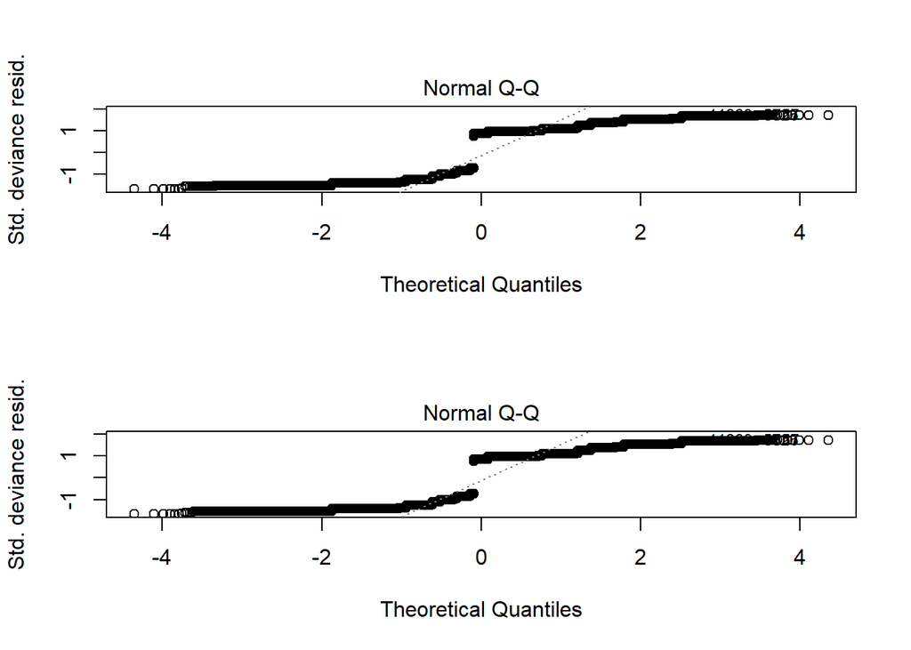

```r
par(mfrow=c(2,1))
plot(logit, 2)
plot(logitIT, 2)
```

Apesar dos dados foram coletados no mesmo ponto do tempo, a necessidade de verificação de autocorrelação se dá pela possibilidade de se encontrar a chamada autocorrelação espacial. Ou seja, diferentemente das séries temporais, a autocorrelação pode aparecer aqui porque os dados foram originalmente coletados em pontos do espaço distintos (escolas e municípios diferentes). É esperado que seja detectada a presença heterocedasticidade no modelo estimado, pelo mesmo ser estimado com dados em corte transversal. Optou-se por não verificar a existência de multicolinearidade pois, segundo Gujarati e Porter (2011), a presença de multicolinearidade é um problema maior apenas quando se busca realizar previsões. A Tabela 7 apresenta os resultados dos testes de autocorrelação e heterocedasticidade para o segundo modelo estimado (incluindo um variávels de interação).

```r
library(lmtest)
library(car)
bptest(logitIT)
```

```
##
##  studentized Breusch-Pagan test
##
## data:  logitIT
## BP = 200.07, df = 7, p-value < 0.00000000000000022
```

```r
dwtest(logitIT)
```

```
##
##  Durbin-Watson test
##
## data:  logitIT
## DW = 1.8602, p-value < 0.00000000000000022
## alternative hypothesis: true autocorrelation is greater than 0
```

```r
bgtest(logitIT)
```

```
##
##  Breusch-Godfrey test for serial correlation of order up to 1
##
## data:  logitIT
## LM test = 364.44, df = 1, p-value < 0.00000000000000022
```

**Tabela 7 - Testes de Autocorrelação e Heterocedasticidade para o Modelo Estimado com Interação**

| **Heterocedasticidade** | Estatística do teste | p-valor |
| --- | --- | --- |
| Breusch-Pagan | 200,07 | 0,0000 |
| **Autocorrelação** |  |  |
| Durbin-Watson | 1,8602 | 0,0000 |
| Breusch-Godfrey | 364,44 | 0,0000 |

Fonte: Elaboração própria a partir de dados do SAEB 2019.

```r
library(sandwich)
coeftest(logitIT,
         vcov = vcovHC(logitIT, type = "HC3"))
```

```
##
## z test of coefficients:
##
##                                Estimate Std. Error  z value
## (Intercept)                    0.108476   0.051915   2.0895
## TX_RESP_Q002Branco             0.267252   0.018226  14.6632
## TX_RESP_Q006BTRUE              0.084073   0.050991   1.6488
## Turno_NTRUE                    0.280041   0.123304   2.2711
## TX_RESP_Q015TRUE              -0.973182   0.017349 -56.0943
## TX_RESP_Q017ETRUE             -0.366091   0.018584 -19.6998
## TX_RESP_Q018BTRUE              0.344371   0.016699  20.6217
## Turno_NTRUE:TX_RESP_Q017ETRUE  0.218078   0.192020   1.1357
##                                           Pr(>|z|)
## (Intercept)                                0.03666 *
## TX_RESP_Q002Branco            < 0.0000000000000002 ***
## TX_RESP_Q006BTRUE                          0.09919 .
## Turno_NTRUE                                0.02314 *
## TX_RESP_Q015TRUE              < 0.0000000000000002 ***
## TX_RESP_Q017ETRUE             < 0.0000000000000002 ***
## TX_RESP_Q018BTRUE             < 0.0000000000000002 ***
## Turno_NTRUE:TX_RESP_Q017ETRUE              0.25608
## ---
## Signif. codes:  0 '***' 0.001 '**' 0.01 '*' 0.05 '.' 0.1 ' ' 1
```

| Var. Depend. | Coef. | Erro-padrão | Estatística z | p-valor |
| --- | --- | --- | --- | --- |
| Intercepto | 0,10847 | 0,05191 | 2,089 | 0,0366 |
| TX_RESP_Q002 | 0,26725 | 0,01822 | 14,663 | 0,0000 |
| TX_RESP_Q006B | 0,08407 | 0,05090 | 1,648 | 0,0991 |
| Turno_N | 0,28004 | 0,12330 | 2,271 | 0,0231 |
| TX_RESP_Q015 | -0,97318 | 0,01734 | -56,094 | 0,0000 |
| TX_RESP_Q017E | -0,36609 | 0,01858 | -19,699 | 0,0000 |
| TX_RESP_Q018B | 0,34437 | 0,01669 | 20,621 | 0,0000 |
| V. Interação | 0,21808 | 0,19202 | 1,135 | 0,2560 |

Fonte: Elaboração própria a partir de dados do SAEB 2019.

Conforme indicado anteriormente, a estimação com a matriz HC3 de White não altera os coeficientes estimados, com a interpretação dos mesmos permanecendo intalterada.A únicas alterações ocorridas podem ser verificadas nas colunas de erro-padrão, estatística Z e p-valor. É importante destacar que não houve nenhuma alteração capaz de modificar a significância estatística individual dos parâmetros.

## Referências

BASSETTO, Camila Fernanda. Background familiar e desempenho escolar: uma abordagem com variáveis binárias a partir dos resultados do Saresp. **Revista Brasileira de Estudos de População**, v. 36, 2019.

BRASIL, Instituto Nacional de Estudos e Pesquisas Anísio Teixeira. **Sistema de Avaliação da Educação Básica 20119**. Disponível em: https://www.gov.br/inep/pt-br/.

FIGUEIRA, Cleonis Viater. **Modelos de regressão logística**. 2006.

GUJARATI, Damodar N.; PORTER, Dawn C. **Econometria Básica**. Tradução de D. Durante; M. Rosemerg; M. L. G. L. Rosa. 5ª ed. Porto Alegre: AMGH, 2011.

IBGE - Instituto Brasileiro de Geografia e estatística. **Pesquisa Nacional por Amostra de Domicílios Contínua - PNADC**, 2020.

KELLSTEDT, Paul M.; WHITTEN, Guy D. **The fundamentals of political science research**. Cambridge University Press, 2018.

MAIA, Sinézio F. **Introdução a Estatística Descritiva: Conceitos e Aplicações.** João Pessoa, 2016. Disponível em: http://salaacoes.blogspot.com/2018/04/curso-de-econometria.html

MELLO, Guiomar Namo. **Políticas públicas de educação**. Estudos Avançados, vol 5. São Paulo. 1991.

SHIRASU, Maitê R.; ARRAES, Ronaldo A. **Determinantes da Evasão e Repetência Escolar**. In: 46º Encontro Nacional de Economia – Anpec, 2015. Disponível em: https://www.anpec.org/encontro/2015/submissão/files_I/i1285f3c3774c3d65741cb278e01e61db39.pdf